# Análise da base IMDB

Avaliação de potencialidades de investimento

## 1. Introdução

### 1.1. Problematização

Na busca por uma oportunidade de investimento na área cinematográfica, o objetivo deste trabalho é identificar qual categoria de filme tem potencial para ser tanto um sucesso financeiro quanto um sucesso de crítica. Mas podendo desprezar um dos critérios caso o outro seja muito atraente.

### 1.2. Sobre a fonte dos dados

Conjunto de dados extraído do site Kaggle. Nele há 28 variáveis e 5.043 linhas abrangendo 4.916 filmes em 100 anos de produção cinematográfica em 66 países.

Acesso aos dados por meio do site https://www.kaggle.com/carolzhangdc/imdb-5000-movie-dataset.

|  | Variable | Description |
| --- | --- | --- |
| 1 | movie_title | Title_of_the_Movie |
| 2 | duration | Duration in minutes |
| 3 | director_name | Name of the Director of the Movie |
| 4 | director_facebook_likes | Number of likes of the Director on his Facebook Page |
| 5 | actor_1_name | Primary actor starring in the movie |
| 6 | actor_1_facebook_likes | Number of likes of the Actor_1 on his/her Facebook Page |
| 7 | actor_2_name | Other actor starring in the movie |
| 8 | actor_2_facebook_likes | Number of likes of the Actor_2 on his/her Facebook Page |
| 9 | actor_3_name | Other actor starring in the movie |
| 10 | actor_3_facebook_likes | Number of likes of the Actor_3 on his/her Facebook Page |

[output cut: 18 more lines]

## 2. Tratando a Base de Dados

### 2.1. Removendo casos sem valor de orçamento ou receita

São 1.152 linhas cujos campos orçamento ou receita não possuem valores. Após eliminar os casos supracitados, a base passará a ter 3.891 linhas.

### 2.2. Removendo filmes duplicados

São 102 títulos de filmes duplicados na base. Após eliminar os casos supracitados, a base passará a ter 3.789 linhas.

### 2.3. Adicionando colunas

Para a análise de viabilidade de investimento no segmento cinematográfico, foi necessário criar 3 novas colunas: Lucro, Margem¹ e ROI² (Retorno sobre o investimento).

*¹Margem = Lucro / Receita* *²ROI = Lucro / Orçamento*

## 3. Análise exploratório da base de dados

### 3.1. Olhando para a distribuição de filmes pela coloração

Considerando a grande volumetria de filmes coloridos produzidos a partir dos anos de 1.980, iremos desconsiderar os filmes produzidos antes dessa data ou cuja a coloração é diferente de colorido. Com isso, serão desconsiderados 206 filmes na continuidade da análise.

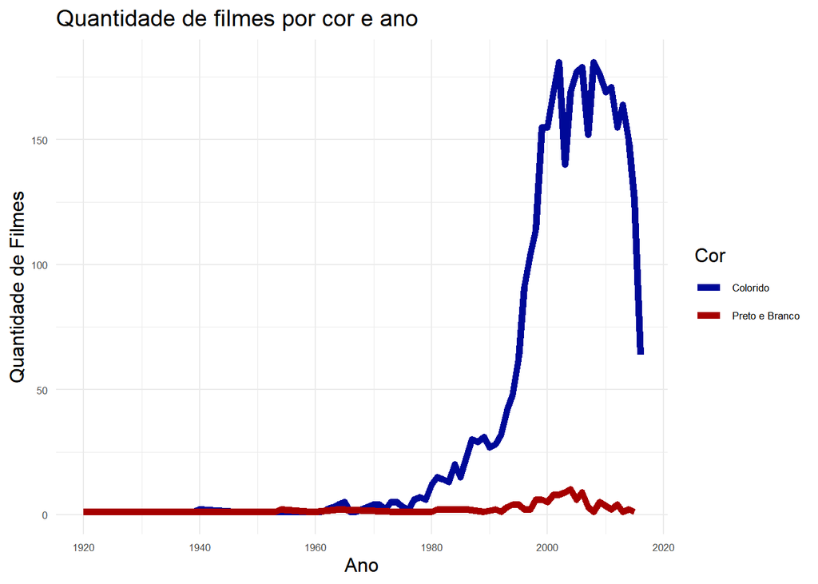

### 3.2. Olhando para a Nota IMDb

Os filmes concentram-se entre as notas 5.5 e 7.5 como ilustrados nos gráficos abaixo.

[figure not shown]

### 3.3. Olhando para o número de curtidas no Facebook

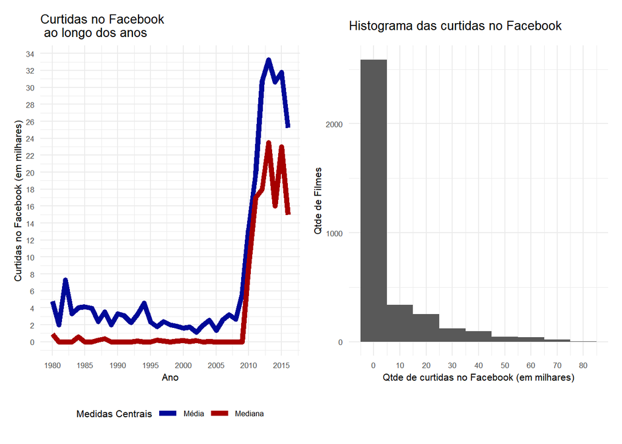

O que é interessante de observar é que esses mesmos filmes que tiveram um aumento representativo no número de curtidas no Facebook não tiveram melhor desempenho na nota IMDb. Isso pode ser um indicativo que o aumento no número de curtidas no facebook esteja mais relacionada a um aumento de popularização do aplicativo atrelada a divulgação do filme na rede social.

### 3.4. Olhando para os gêneros dos filmes

Pode-se observar que a nota IMDb não se mostrou um grande diferencial entre as diferentes gêneros de filmes.analisado o desempenho desses filmes, olhando para o *Lucro*, para a *Margem* e *ROI*, existe uma variação maior entre os gêneros. Isto posto, a nota IMDb não se mostra um fator diferenciador relevante.

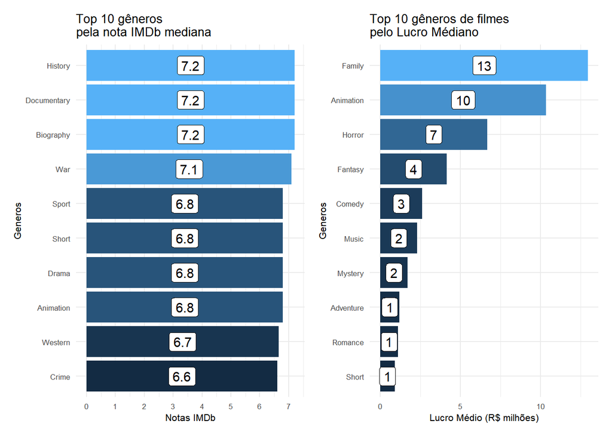

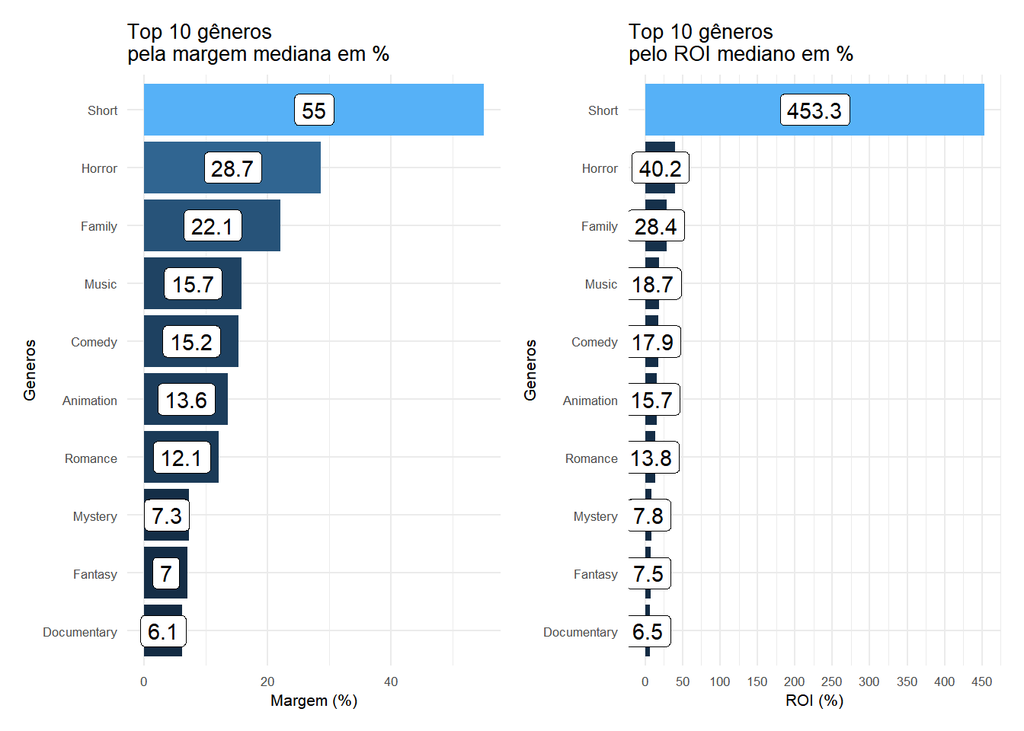

### 3.4. Olhando para o Lucro, Margem e ROI

Como vistos nos gráficos acima, o gênero *family* foi o que apresentou o maior lucro mediano e esta na terceira posição se olhado para a *Margem* e para o *ROI*. Este gênero tem um grande potencial de sucesso financeiro.

Mas a tomada de decisão for orientada por filmes com maior margem ou ROI, em disparado os curta-metragens apresentam maior potencial. Para o gênero *Short*, o lucro representa, em média, 55% das receitas enquanto que o gênero *family* chega a 22%. Um outro dado interessantes é que o gênero *Short* indicou que tem um potencial estrondoso para gerar lucro em relação ao dinheiro aplicado. O que indica, que este gênero seria o mais indicado, por gerar mais retorno para o valor investido.

Muito bom pra ser verdade!!!

O gênero *Short* só tem 2 filmes na base analisada, amostra muito pequena para batermos o “martelo” ao dizer que investir 1 dolar nesse tipo de filmes o retorno esperado será de 4,53 dolares. Você compraria esse risco? Investiria confiando em números produzidos com base em 2 observações?

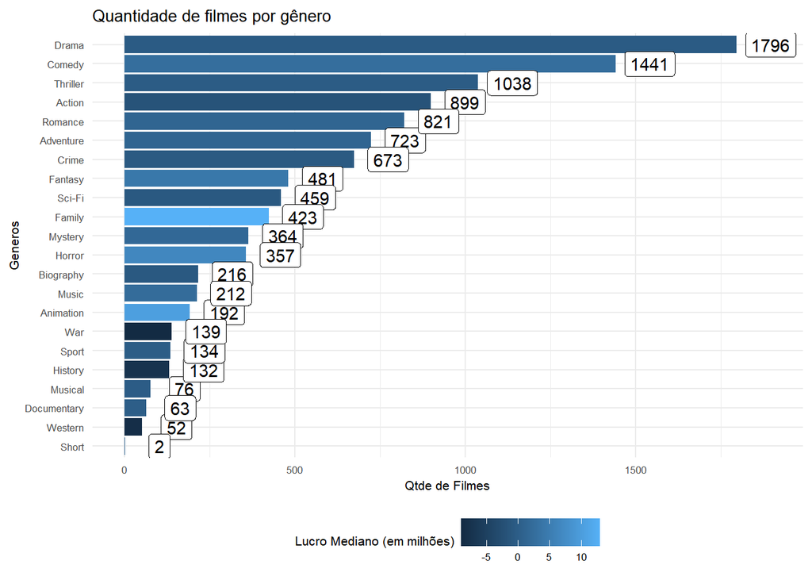

## 4. Concluindo

Diante do exposto, olhar para a nota do IMDb não é conclusivo. Mas também é preciso avaliar com calma para o lucro, margem e ROI. Uma vez que, o gênero de filme que apresentou melhores indicadores tinha uma amostra insuficiente para gerar algum nivel de segurança sobre os índices apurados.

Diante dos indicadores utilizados e do que observamos, ainda assim, apostaria no ROI como melhor indicador de potencialização de retorno de um dado investimento, uma vez que a proposta desse indicador é capturar a relação entre o lucro gerado no projeto e seu custo, transmitindo uma ideia de rentabilidade e deste modo, sendo possível comparar com outros ativos do mercado financeiro, e então decidir se vale aplicar nesse tipo de ativo ou em algum outro. Também cabe ressaltar que aqui não fizemos nenhuma correção monetária ou ajustes em virtude do tempo em que cada filmes foi produzido, tão pouco calculamos o payback, TIR ou qualquer outro indicador financeiro que nortea que contribuem para a tomada de decisão.

## 5. Sobre o autor

Ana Rafaela Torres, bacharel em ciências atuariais pela Universidade Católica de São Paulo.

E-mail: anarafaelatorres.art@hotmail.com

Linkedin: linkedin.com/in/ana-rafaela-torres